# Part 1: Getting Started and Basic Text Analysis

Kenneth Benoit and Paul Nulty

2nd December 2015

#### Preliminaries: Installation

First, you need to have **quanteda** installed. You can do this from inside RStudio, from the Tools…Install Packages menu, or simply using

```r
install.packages("quanteda", dependencies = TRUE)
```

(Optional) You can install some additional corpus data from **quantedaData** using

```r
## the devtools package is required to install quanteda from Github
devtools::install_github("kbenoit/quantedaData")
```

Note that on **Windows platforms**, it is also recommended that you install the [RTools suite](https://cran.r-project.org/bin/windows/Rtools/), and for **OS X**, that you install [XCode](https://itunes.apple.com/gb/app/xcode/id497799835?mt=12) from the App Store.

#### Test your setup

Run the rest of this file to test your setup. You must have quanteda installed in order for this next step to succeed.

```r
require(quanteda)
```

Now summarize some texts in the Irish 2010 budget speech corpus:

```r
summary(ie2010Corpus)
```

```
## Corpus consisting of 14 documents.
##
##                                   Text Types Tokens Sentences year debate
##        2010_BUDGET_01_Brian_Lenihan_FF  1754   7916       404 2010 BUDGET
##       2010_BUDGET_02_Richard_Bruton_FG   995   4086       217 2010 BUDGET
##         2010_BUDGET_03_Joan_Burton_LAB  1521   5790       309 2010 BUDGET
##        2010_BUDGET_04_Arthur_Morgan_SF  1499   6510       345 2010 BUDGET
##          2010_BUDGET_05_Brian_Cowen_FF  1544   5964       252 2010 BUDGET
##           2010_BUDGET_06_Enda_Kenny_FG  1087   3896       155 2010 BUDGET
##      2010_BUDGET_07_Kieran_ODonnell_FG   638   2086       133 2010 BUDGET
##       2010_BUDGET_08_Eamon_Gilmore_LAB  1123   3807       202 2010 BUDGET
##     2010_BUDGET_09_Michael_Higgins_LAB   457   1149        44 2010 BUDGET
##        2010_BUDGET_10_Ruairi_Quinn_LAB   415   1181        60 2010 BUDGET
##      2010_BUDGET_11_John_Gormley_Green   381    939        50 2010 BUDGET
##        2010_BUDGET_12_Eamon_Ryan_Green   486   1519        90 2010 BUDGET
##      2010_BUDGET_13_Ciaran_Cuffe_Green   426   1144        45 2010 BUDGET
##  2010_BUDGET_14_Caoimhghin_OCaolain_SF  1110   3699       177 2010 BUDGET
##  number      foren     name party
##      01      Brian  Lenihan    FF
##      02    Richard   Bruton    FG
##      03       Joan   Burton   LAB
##      04     Arthur   Morgan    SF
##      05      Brian    Cowen    FF
##      06       Enda    Kenny    FG
##      07     Kieran ODonnell    FG
##      08      Eamon  Gilmore   LAB
##      09    Michael  Higgins   LAB
##      10     Ruairi    Quinn   LAB
##      11       John  Gormley Green
##      12      Eamon     Ryan Green
##      13     Ciaran    Cuffe Green
##      14 Caoimhghin OCaolain    SF
##
## Source:  /home/paul/Dropbox/code/quantedaData/* on x86_64 by paul
## Created: Tue Sep 16 15:58:21 2014
## Notes:
```

Create a document-feature matrix from this corpus, removing stop words:

```r
ieDfm <- dfm(ie2010Corpus, ignoredFeatures = c(stopwords("english"), "will"), stem = TRUE)
```

```
## Creating a dfm from a corpus ...
##    ... lowercasing
##    ... tokenizing
##    ... indexing documents: 14 documents
##    ... indexing features: 4,881 feature types
##    ... stemming features (English)
##    ... removed 118 features, from 175 supplied (glob) feature types
##    ... created a 14 x 4763 sparse dfm
##    ... complete.
## Elapsed time: 0.602 seconds.
```

Look at the top occuring features:

```r
topfeatures(ieDfm)
```

```
##     people     budget government     public   minister        tax
##        266        260        236        179        170        163
##    economy        pay       jobs    billion
##        160        122        120        119
```

Make a word cloud:

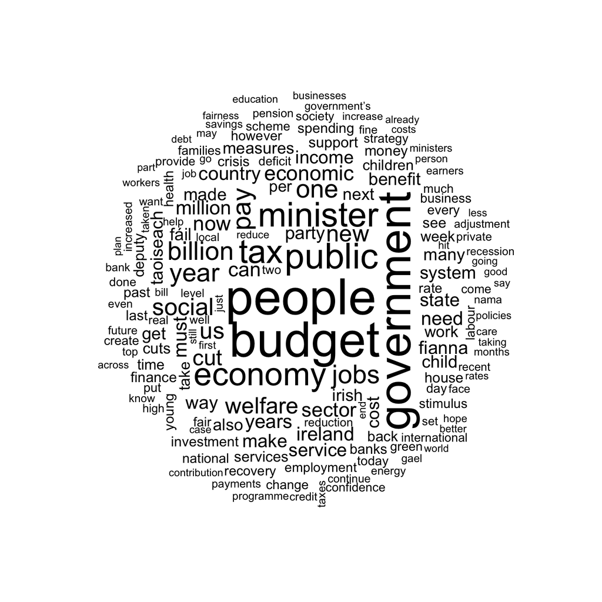

```r
plot(ieDfm, min.freq=25, random.order=FALSE)
```

If you got this far, congratulations!

### Three ways to create a `corpus` object

**quanteda can construct a `corpus` object** from several input sources:

1. a character vector object

   ```r
   require(quanteda)
   myTinyCorpus <- corpus(inaugTexts[1:2], notes = "Just G.W.")
   summary(myTinyCorpus)
   ```

   ```
   ## Corpus consisting of 2 documents.
   ##
   ##             Text Types Tokens Sentences
   ##  1789-Washington   595   1430        24
   ##  1793-Washington    90    135         4
   ##
   ## Source:  /Users/kbenoit/Dropbox/GitHub/ITAUR-Short/1_getting_started/* on x86_64 by kbenoit
   ## Created: Tue Dec  1 13:46:00 2015
   ## Notes:   Just G.W.
   ```

2. a `VCorpus` object from the **tm** package, and

   ```r
   require(tm)
   data(crude, package = "tm")
   myTmCorpus <- corpus(crude)
   summary(myTmCorpus, 5)
   ```

   ```
   ## Corpus consisting of 20 documents, showing 5 documents.
   ##
   ##  Text Types Tokens Sentences                     author
   ##   127    58     92        12                       <NA>
   ##   144   227    443        52 BY TED D'AFFLISIO, Reuters
   ##   191    43     55         9                       <NA>
   ##   194    52     69        10                       <NA>
   ##   211    64     93        12                       <NA>
   ##        datetimestamp description
   ##  1987-02-26 17:00:56
   ##  1987-02-26 17:34:11
   ##  1987-02-26 18:18:00
   ##  1987-02-26 18:21:01
   ##  1987-02-26 19:00:57
   ##                                          heading  id language
   ##         DIAMOND SHAMROCK (DIA) CUTS CRUDE PRICES 127       en
   ##  OPEC MAY HAVE TO MEET TO FIRM PRICES - ANALYSTS 144       en
   ##        TEXACO CANADA <TXC> LOWERS CRUDE POSTINGS 191       en
   ##        MARATHON PETROLEUM REDUCES CRUDE POSTINGS 194       en
   ##        HOUSTON OIL <HO> RESERVES STUDY COMPLETED 211       en
   ##             origin topics lewissplit     cgisplit oldid places people orgs
   ##  Reuters-21578 XML    YES      TRAIN TRAINING-SET  5670    usa   <NA> <NA>
   ##  Reuters-21578 XML    YES      TRAIN TRAINING-SET  5687    usa   <NA> opec
   ##  Reuters-21578 XML    YES      TRAIN TRAINING-SET  5734 canada   <NA> <NA>
   ##  Reuters-21578 XML    YES      TRAIN TRAINING-SET  5737    usa   <NA> <NA>
   ##  Reuters-21578 XML    YES      TRAIN TRAINING-SET  5754    usa   <NA> <NA>
   ##  exchanges
   ##       <NA>
   ##       <NA>
   ##       <NA>
   ##       <NA>
   ##       <NA>
   ##
   ## Source:  Converted from tm VCorpus 'crude'
   ## Created: Tue Dec  1 13:46:01 2015
   ## Notes:
   ```

   ```r
   detach()
   ```

3. a `corpusSource` object, created by `textfile()`.

   In most cases you will need to load input files from outside of R, so you will use this third method. The remainder of this tutorial focuses on `textfile()`, which is designed to be a simple, powerful, and all-purpose method to load texts.

### Using `textfile()` to import texts

In the simplest case, we would like to load a set of texts in plain text files from a single directory. To do this, we use the `textfile` command, and use the ‘glob’ operator ’*’ to indicate that we want to load multiple files:

```r
myCorpus <- corpus(textfile(file='inaugural/*.txt'))
myCorpus <- corpus(textfile(file='sotu/*.txt'))
```

Often, we have metadata encoded in the names of the files. For example, the inaugural addresses contain the year and the president’s name in the name of the file. With the `docvarsfrom` argument, we can instruct the `textfile` command to consider these elements as document variables.

```r
mytf <- textfile("inaugural/*.txt", docvarsfrom="filenames", dvsep="-", docvarnames=c("Year", "President"))
inaugCorpus <- corpus(mytf)
summary(inaugCorpus, 5)
```

```
## Corpus consisting of 57 documents, showing 5 documents.
##
##                 Text Types Tokens Sentences Year  President
##  1789-Washington.txt   595   1430        24 1789 Washington
##  1793-Washington.txt    90    135         4 1793 Washington
##       1797-Adams.txt   794   2318        37 1797      Adams
##   1801-Jefferson.txt   681   1726        42 1801  Jefferson
##   1805-Jefferson.txt   776   2166        45 1805  Jefferson
##
## Source:  /Users/kbenoit/Dropbox/GitHub/ITAUR-Short/1_getting_started/* on x86_64 by kbenoit
## Created: Tue Dec  1 13:46:03 2015
## Notes:
```

If the texts and document variables are stored separately, we can easily add document variables to the corpus, as long as the data frame containing them is of the same length as the texts:

```r
SOTUdocvars <- read.csv("SOTU_metadata.csv", stringsAsFactors = FALSE)
SOTUdocvars$Date <- as.Date(SOTUdocvars$Date, "%B %d, %Y")
SOTUdocvars$delivery <- as.factor(SOTUdocvars$delivery)
SOTUdocvars$type <- as.factor(SOTUdocvars$type)
SOTUdocvars$party <- as.factor(SOTUdocvars$party)
SOTUdocvars$nwords <- NULL

sotuCorpus <- corpus(textfile(file='sotu/*.txt'), encodingFrom = "UTF-8-BOM")
docvars(sotuCorpus) <- SOTUdocvars
```

Another common case is that our texts are stored alongside the document variables in a structured file, such as a json, csv or excel file. The textfile command can read in the texts and document variables simultaneously from these files when the name of the field containing the texts is specified.

```r
tf1 <- textfile(file='inaugTexts.csv', textField = 'inaugSpeech')
myCorpus <- corpus(tf1)
tf2 <- textfile("text_example.csv", textField = "Title")
myCorpus <- corpus(tf2)
head(docvars(tf2))
```

```
##   VOTE DocumentNo CouncilLink         Year Date.of.Meeting VotingDate
## 1    1    5728/99             Jan-Dec 1999      08/02/1999 08/02/1999
## 2    2    5728/99             Jan-Dec 1999      08/02/1999 08/02/1999
## 3    3    5728/99             Jan-Dec 1999      08/02/1999 08/02/1999
## 4    4    5728/99             Jan-Dec 1999      08/02/1999 08/02/1999
## 5    5    5728/99             Jan-Dec 1999      08/02/1999 08/02/1999
## 6    6    6327/99             Jan-Dec 1999      22/02/1999 22/02/1999
##                                       Policy.area Council.configuration
## 1 Employment, Education, Culture & Social Affairs                ECOFIN
## 2 Employment, Education, Culture & Social Affairs                ECOFIN
## 3 Employment, Education, Culture & Social Affairs                ECOFIN
## 4                         Agriculture & Fisheries                ECOFIN
## 5                  Transport & Telecommunications                ECOFIN
## 6                    Economic & Financial Affairs       General Affairs
##   Procedure
## 1         1
## 2         1
## 3         0
## 4         0
## 5         0
## 6         0
```

Once the we have loaded a corpus with some document level variables, we can subset the corpus using these variables, create document-feature matrices by aggregating on the variables, or extract the texts concatenated by variable.

```r
recentCorpus <- subset(inaugCorpus, Year > 1980)
oldCorpus <- subset(inaugCorpus, Year < 1880)

require(dplyr)
demCorpus <- subset(sotuCorpus, party == 'Democratic')
demFeatures <- dfm(demCorpus, ignoredFeatures=stopwords('english')) %>%
    trim(minDoc=3, minCount=5) %>% weight(type='tfidf') %>% topfeatures
```

```
## Creating a dfm from a corpus ...
##    ... lowercasing
##    ... tokenizing
##    ... indexing documents: 89 documents
##    ... indexing features: 19,512 feature types
##    ... removed 166 features, from 174 supplied (glob) feature types
##    ... created a 89 x 19346 sparse dfm
##    ... complete.
## Elapsed time: 1.57 seconds.
## Removing features occurring fewer than 5 times: 11948
## Removing features occurring in fewer than 3 documents: 10173
```

```r
repCorpus <- subset(sotuCorpus, party == 'Republican')
repFeatures <- dfm(repCorpus, ignoredFeatures=stopwords('english')) %>%
    trim(minDoc=3, minCount=5) %>% weight(type='tfidf') %>% topfeatures
```

```
## Creating a dfm from a corpus ...
##    ... lowercasing
##    ... tokenizing
##    ... indexing documents: 92 documents
##    ... indexing features: 19,794 feature types
##    ... removed 162 features, from 174 supplied (glob) feature types
##    ... created a 92 x 19632 sparse dfm
##    ... complete.
## Elapsed time: 1.122 seconds.
## Removing features occurring fewer than 5 times: 11983
## Removing features occurring in fewer than 3 documents: 10121
```

The `quanteda` corpus objects can be combined using the `+` operator:

```r
inaugCorpus <- demCorpus + repCorpus
allFeatures <- dfm(inaugCorpus, ignoredFeatures=stopwords('english'))%>%
    trim(minDoc=3, minCount=5) %>% weight(type='tfidf') %>% topfeatures
```

```
## Creating a dfm from a corpus ...
##    ... lowercasing
##    ... tokenizing
##    ... indexing documents: 181 documents
##    ... indexing features: 26,193 feature types
##    ... removed 167 features, from 174 supplied (glob) feature types
##    ... created a 181 x 26026 sparse dfm
##    ... complete.
## Elapsed time: 2.674 seconds.
## Removing features occurring fewer than 5 times: 15558
## Removing features occurring in fewer than 3 documents: 13237
```

It should also be possible to load a zip file containing texts directly from a url. However, whether this operation succeeds or not can depend on access permission settings on your particular system (i.e. fails on Windows):

```r
immigfiles <- textfile("https://github.com/kbenoit/ME114/raw/master/day8/UKimmigTexts.zip")
mycorpus <- corpus(immigfiles)
summary(mycorpus)
```